# Proyecto

# AB - UNIT 24 - ADVANCED PROGRAMMING FOR DATA ANALYSIS

## Daniel Granda Granda

### Introducción:

El dataset que he elegido es “Spotify Most Streamed Songs” que contiene información sobre las canciones más reproducidas en Spotify. Cada columna representa una canción, con las siguientes características:

- track_name: Nombre de la canción.
- artist(s)_name: Nombre(s) del/los artista(s) de la canción
- artist_count: Número de artistas que han participado en la canción
- released_year, released_month,released_day:Fecha de lanzamiento.
- in_spotify_playlists: Número de playlists de Spotify en las que aparece la canción.
- in_spotify_charts: Número de veces que la canción aparece en las listas de spotify.
- streams: Número total de reproducciones en Spotify.
- in_apple_playlists: Número de Playlist de Apple Music en las que aparece la canción.
- danceability_%, energy_%, instrumentalness_% ,etc: Son atributos de audio que describen características de la cancion en porcentajes ( la bailabilidad, instrumentalidad, energía, etc).

## Objetivo del análisis

El objetivo para este dataset, será analizar tendencias y características de las canciones más reproducidas. Algunas preguntas que nos podríamos hacer son:

¿Qué canciones son las más populares?

¿Quiénes son los artistas que tienen más canciones entre las populares?

¿Habrá alguna relación entre las características del audio y el éxito de reproducciones (streams)?

¿Cómo influye el número de listas de reproducción en el éxito de una canción en base a las reproducciones(streams)?

Podremos identificar a los artistas más reproducidos en base a un análisis de las canciones más populares.

Podremos saber si por ejemplo una bailabilidad alta o una energía alta fueran indicativos de que una canción sea más o menos atractiva para el público.

Analizar si una canción que está en más listas, también tiene más reproducciones.

### Combinación de columnas

Combinamos las columnas de released_year, released_month y released_day en una sola llamada released_date en formato Date.

```r
library(dplyr)
library(readr)

spotify_data <- read_csv("Spotify Most Streamed Songs.csv")
spotify_data$release_date <- as.Date(paste(spotify_data$released_year, spotify_data$released_month, spotify_data$released_day, sep = "-"))

spotify_data$released_year <- NULL
spotify_data$released_month <- NULL
spotify_data$released_day <- NULL

head(spotify_data)
```

| track_name | artist(s)_name | artist_count | in_spotify_playlists | in_spotify_charts | streams | in_apple_playlists | in_apple_charts | in_deezer_playlists | in_deezer_charts | in_shazam_charts | bpm | key | mode | danceability_% | valence_% | energy_% | acousticness_% | instrumentalness_% | liveness_% | speechiness_% | cover_url | release_date |
| --- | --- | --- | --- | --- | --- | --- | --- | --- | --- | --- | --- | --- | --- | --- | --- | --- | --- | --- | --- | --- | --- | --- |
| Seven (feat. Latto) (Explicit Ver.) | Latto, Jung Kook | 2 | 553 | 147 | 141381703 | 43 | 263 | 45 | 10 | 826 | 125 | B | Major | 80 | 89 | 83 | 31 | 0 | 8 | 4 | Not Found | 2023-07-14 |
| LALA | Myke Towers | 1 | 1474 | 48 | 133716286 | 48 | 126 | 58 | 14 | 382 | 92 | C# | Major | 71 | 61 | 74 | 7 | 0 | 10 | 4 | https://i.scdn.co/image/ab67616d0000b2730656d5ce813ca3cc4b677e05 | 2023-03-23 |
| vampire | Olivia Rodrigo | 1 | 1397 | 113 | 140003974 | 94 | 207 | 91 | 14 | 949 | 138 | F | Major | 51 | 32 | 53 | 17 | 0 | 31 | 6 | https://i.scdn.co/image/ab67616d0000b273e85259a1cae29a8d91f2093d | 2023-06-30 |
| Cruel Summer | Taylor Swift | 1 | 7858 | 100 | 800840817 | 116 | 207 | 125 | 12 | 548 | 170 | A | Major | 55 | 58 | 72 | 11 | 0 | 11 | 15 | https://i.scdn.co/image/ab67616d0000b273e787cffec20aa2a396a61647 | 2019-08-23 |
| WHERE SHE GOES | Bad Bunny | 1 | 3133 | 50 | 303236322 | 84 | 133 | 87 | 15 | 425 | 144 | A | Minor | 65 | 23 | 80 | 14 | 63 | 11 | 6 | https://i.scdn.co/image/ab67616d0000b273ab5c9cd818ad6ed3e9b79cd1 | 2023-05-18 |
| Sprinter | Dave, Central Cee | 2 | 2186 | 91 | 183706234 | 67 | 213 | 88 | 17 | 946 | 141 | C# | Major | 92 | 66 | 58 | 19 | 0 | 8 | 24 | https://i.scdn.co/image/ab67616d0000b273e3a09a9ae3f1fa102c110e60 | 2023-06-01 |

```r
View(spotify_data)
```

### Gráfico Barras Top 10 Canciones

En este gráfico de barras podemos observar las 10 canciones mas reproducidad de forma clara con las barras horizontales.

```r
library(ggplot2)
library(dplyr)
library(readr)

spotify_data <- read_csv("Spotify Most Streamed Songs.csv")
head(spotify_data)
```

| track_name | artist(s)_name | artist_count | released_year | released_month | released_day | in_spotify_playlists | in_spotify_charts | streams | in_apple_playlists | in_apple_charts | in_deezer_playlists | in_deezer_charts | in_shazam_charts | bpm | key | mode | danceability_% | valence_% | energy_% | acousticness_% | instrumentalness_% | liveness_% | speechiness_% | cover_url |
| --- | --- | --- | --- | --- | --- | --- | --- | --- | --- | --- | --- | --- | --- | --- | --- | --- | --- | --- | --- | --- | --- | --- | --- | --- |
| Seven (feat. Latto) (Explicit Ver.) | Latto, Jung Kook | 2 | 2023 | 7 | 14 | 553 | 147 | 141381703 | 43 | 263 | 45 | 10 | 826 | 125 | B | Major | 80 | 89 | 83 | 31 | 0 | 8 | 4 | Not Found |
| LALA | Myke Towers | 1 | 2023 | 3 | 23 | 1474 | 48 | 133716286 | 48 | 126 | 58 | 14 | 382 | 92 | C# | Major | 71 | 61 | 74 | 7 | 0 | 10 | 4 | https://i.scdn.co/image/ab67616d0000b2730656d5ce813ca3cc4b677e05 |
| vampire | Olivia Rodrigo | 1 | 2023 | 6 | 30 | 1397 | 113 | 140003974 | 94 | 207 | 91 | 14 | 949 | 138 | F | Major | 51 | 32 | 53 | 17 | 0 | 31 | 6 | https://i.scdn.co/image/ab67616d0000b273e85259a1cae29a8d91f2093d |
| Cruel Summer | Taylor Swift | 1 | 2019 | 8 | 23 | 7858 | 100 | 800840817 | 116 | 207 | 125 | 12 | 548 | 170 | A | Major | 55 | 58 | 72 | 11 | 0 | 11 | 15 | https://i.scdn.co/image/ab67616d0000b273e787cffec20aa2a396a61647 |
| WHERE SHE GOES | Bad Bunny | 1 | 2023 | 5 | 18 | 3133 | 50 | 303236322 | 84 | 133 | 87 | 15 | 425 | 144 | A | Minor | 65 | 23 | 80 | 14 | 63 | 11 | 6 | https://i.scdn.co/image/ab67616d0000b273ab5c9cd818ad6ed3e9b79cd1 |
| Sprinter | Dave, Central Cee | 2 | 2023 | 6 | 1 | 2186 | 91 | 183706234 | 67 | 213 | 88 | 17 | 946 | 141 | C# | Major | 92 | 66 | 58 | 19 | 0 | 8 | 24 | https://i.scdn.co/image/ab67616d0000b273e3a09a9ae3f1fa102c110e60 |

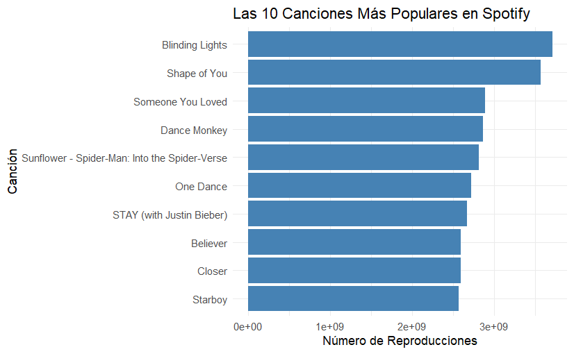

```r
spotify_data$streams <- as.numeric(spotify_data$streams)
top_songs <- spotify_data %>%
  arrange(desc(streams)) %>%
  slice_head(n = 10)


ggplot(top_songs, aes(x = reorder(track_name, streams), y = streams)) +
  geom_bar(stat = "identity", fill = "steelblue") +
  labs(
    title = "Las 10 Canciones Más Populares en Spotify",
    x = "Canción",
    y = "Número de Reproducciones"
  ) +
  coord_flip() +
  theme_minimal()
```

### Gráfico Top 10 artistas + Histograma + Desviación Estándar

En el primer gráfico podemos observar a los 10 artistas más populares en Spotify, basándonos en el total de reproducciones que tiene sus canciones. Con esta infromación podemos entender las tenedencias en la música actual y qué artistas son los que tienen un mayor impacto.

El histograma viene bien para ver la distribución de las reproducciones entre los artistas. Nos permite identificar si la mayoría de los artistas tienen un número similar de reproducciones o si hay algunos con valores mucho más altos o bajos.

Estas estadísticas son clave para entender la distribución de las reproducciones entre los artistas. La desviación estándar es particularmente útil para conocer si las reproducciones están distribuidas de manera uniforme o si hay artistas con mucho más éxito que otros.

Explicación:

La desviación estándar (std_dev_streams) ayuda a comprender la variabilidad en las reproducciones de los artistas.

Una desviación estándar alta indica una gran disparidad en el éxito entre los artistas más populares, mientras que una baja sugiere un éxito más uniforme entre ellos.

**Conclusión**: El código proporciona un análisis descriptivo y visual de los artistas más populares en Spotify, permitiendo una mejor comprensión de las distribuciones de las reproducciones y la identificación de los artistas más exitosos.

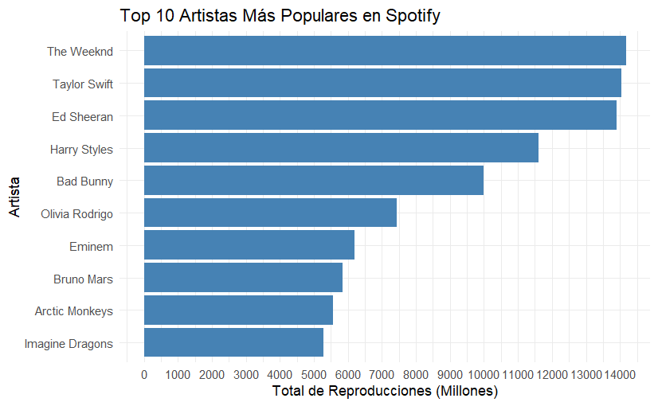

```r
library(dplyr)
library(ggplot2)
library(readr)

# Cargar los datos
spotify_data <- read_csv("Spotify Most Streamed Songs.csv")
# Asegurar que la columna 'streams' esté en formato numérico
spotify_data$streams <- as.numeric(spotify_data$streams)
# Análisis de los artistas más populares
popular_artists <- spotify_data %>%
  group_by(`artist(s)_name`) %>%
  summarise(total_streams = sum(streams, na.rm = TRUE) / 1e6) %>%
  arrange(desc(total_streams))

# Tomamos los 10 primeros artistas más populares
top_10_artists <- head(popular_artists, 10)

# Gráfico de barras
ggplot(top_10_artists, aes(x = reorder(`artist(s)_name`, total_streams), y = total_streams)) +
  geom_bar(stat = "identity", fill = "steelblue") +
  labs(
    title = "Top 10 Artistas Más Populares en Spotify",
    x = "Artista",
    y = "Total de Reproducciones (Millones)"
  ) +
  scale_y_continuous(breaks = seq(0, max(top_10_artists$total_streams), by = 1000)) +
  coord_flip() +
  theme_minimal()
```

```r
# Análisis estadístico con desviación estándar
summary_stats <- popular_artists %>%
  summarise(
    total_artists = n(),
    avg_streams = mean(total_streams, na.rm = TRUE),
    max_streams = max(total_streams, na.rm = TRUE),
    min_streams = min(total_streams, na.rm = TRUE),
    std_dev_streams = sd(total_streams, na.rm = TRUE)  # Desviación estándar añadida
  )

# Mostrar estadísticas
print(summary_stats)
```

| total_artists | avg_streams | max_streams | min_streams | std_dev_streams |
| --- | --- | --- | --- | --- |
| 645 | 758.8509 | 14185.55 | 0 | 1400.37 |

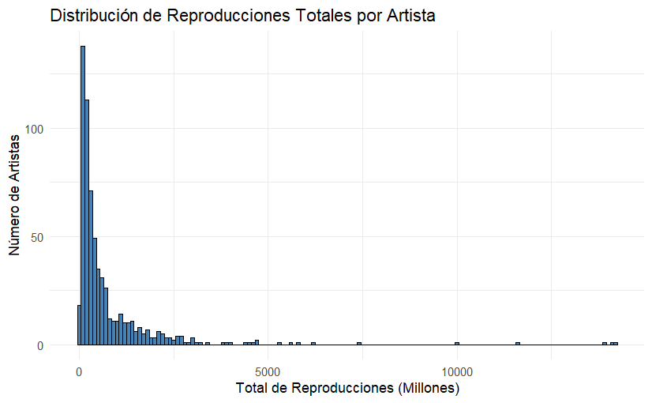

```r
ggplot(popular_artists, aes(x = total_streams)) +
  geom_histogram(binwidth = 100, fill = "steelblue", color = "black") +
  labs(
    title = "Distribución de Reproducciones Totales por Artista",
    x = "Total de Reproducciones (Millones)",
    y = "Número de Artistas"
  ) +
  theme_minimal()
```

```r
NA
NA
NA
```

### Gráfico mapa de calor Correlación

En este gráfico podemos obervar un mapa de calor en el que se visualiza la correlación entre las caracterísiticas de audio de las canciones mas reproducidas en Shopify y su número de reproducciones.

La matriz de correlación es una herramienta clave para entender cómo se relacionan las variables entre sí. En este caso, queremos entender cómo las características de audio se correlacionan con el número de reproducciones de las canciones.

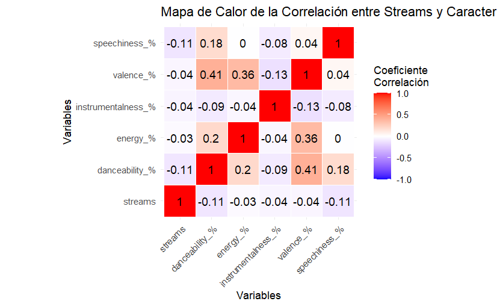

```r
library(dplyr)
library(readr)
library(ggplot2)
library(reshape2)

spotify_data <- read_csv("Spotify Most Streamed Songs.csv")
spotify_data <- spotify_data %>%
  select(streams, `danceability_%`, `energy_%`, `instrumentalness_%`, `valence_%`, `speechiness_%`) %>%
  mutate(across(everything(), as.numeric))
correlation_matrix <- cor(spotify_data, use = "complete.obs")

correlation_data <- melt(correlation_matrix)

ggplot(correlation_data, aes(Var1, Var2, fill = value)) +
  geom_tile(color = "white") +
  scale_fill_gradient2(low = "blue", high = "red", mid = "white", midpoint = 0,
                       limit = c(-1, 1), space = "Lab",
                       name = "Coeficiente\nCorrelación") +
  theme_minimal() +
  theme(axis.text.x = element_text(angle = 45, vjust = 1, hjust = 1)) +
  labs(title = "Mapa de Calor de la Correlación entre Streams y Características de Audio",
       x = "Variables",
       y = "Variables") +
  coord_fixed() +
  geom_text(aes(label = round(value, 2)), color = "black", size = 4) # Añadir los números dentro de las casillas
```

```r
NA
NA
NA
```

### Conclusión:

Podemos observar que las características de audio como la bailabilidad o la energía no tienen una relación fuerte con el éxito de la canción en términos de reproducciones en Spotify

### Análisis Correlación Gráfico de Dispersión

Este análisis muestra cómo el número de listas de reproducción en Apple Music y Spotify se correlaciona con el número de reproducciones de las canciones. Para ello utilizamos dos gráficos de dispersión (Azul para Apple Music) (Verde para Spotify). He decidido utilizar este tipo de gráfico ya que podemos visualizar de manera clara la tendencia que siguen los puntos.

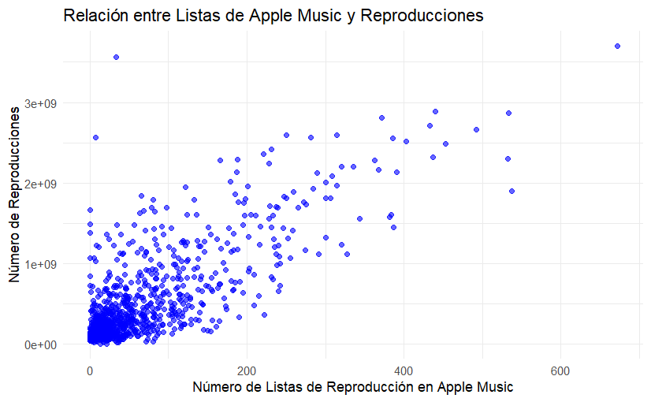

```r
library(ggplot2)
library(readr)


spotify_data <- read_csv("Spotify Most Streamed Songs.csv")
spotify_data$streams <- as.numeric(spotify_data$streams)
ggplot(spotify_data, aes(x = in_apple_playlists, y = streams)) +
  geom_point(alpha = 0.6, color = "blue") +
  labs(
    title = "Relación entre Listas de Apple Music y Reproducciones",
    x = "Número de Listas de Reproducción en Apple Music",
    y = "Número de Reproducciones"
  ) +
  theme_minimal()
```

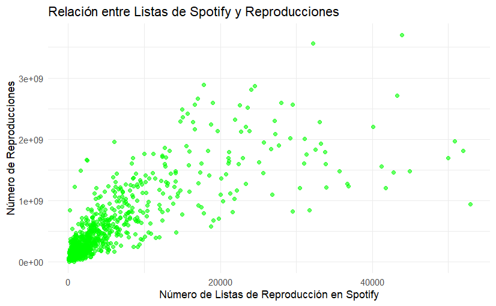

```r
ggplot(spotify_data, aes(x = in_spotify_playlists, y = streams)) +
  geom_point(alpha = 0.6, color = "green") +
  labs(
    title = "Relación entre Listas de Spotify y Reproducciones",
    x = "Número de Listas de Reproducción en Spotify",
    y = "Número de Reproducciones"
  ) +
  theme_minimal()
```

```r
correlation_spotify <- cor(spotify_data$in_spotify_playlists, spotify_data$streams, use = "complete.obs")
correlation_apple <- cor(spotify_data$in_apple_playlists, spotify_data$streams, use = "complete.obs")


cat("Correlación entre in_spotify_playlists y streams:", correlation_spotify, "\n")
```

```
Correlación entre in_spotify_playlists y streams: 0.7898222
```

```r
cat("Correlación entre in_apple_playlists y streams:", correlation_apple, "\n")
```

```
Correlación entre in_apple_playlists y streams: 0.772063
```

### Conclusión:

En los gráficos se puede observar que cuando las canciones aparecen en más listas, sus reproducciones también aumnetan.

### Gráfico mes de lanzamiento

En este gráfico voy a analizar si el mes de lanzamiento de la canción, influye en el número de reproducciones.

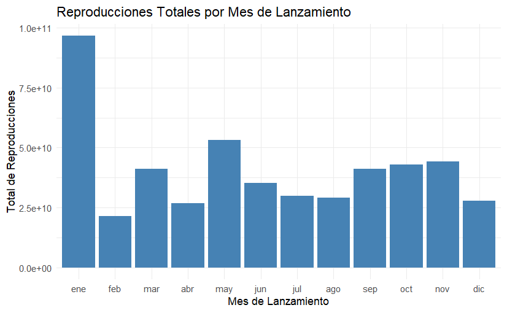

```r
library(dplyr)
library(ggplot2)
library(lubridate)
# Crear columna de fecha
spotify_data <- spotify_data %>%
  mutate(
    release_date = make_date(released_year, released_month, released_day),
    month = month(release_date, label = TRUE)
  )

# Sumar las reproducciones por mes
monthly_streams <- spotify_data %>%
  group_by(month) %>%
  summarise(total_streams = sum(streams, na.rm = TRUE))

# Gráfico de la suma de reproducciones por mes
ggplot(monthly_streams, aes(x = month, y = total_streams)) +
  geom_bar(stat = "identity", fill = "steelblue") +
  labs(
    title = "Reproducciones Totales por Mes de Lanzamiento",
    x = "Mes de Lanzamiento",
    y = "Total de Reproducciones"
  ) +
  theme_minimal()
```

### **Conclusiones:**

1. **Meses con más reproducciones:**

   Si los meses de enero y mayo tienen las barras más altas en el gráfico, se puede concluir que estas fechas tienen un mayor volumen de reproducciones, lo que podría sugerir que las canciones lanzadas en esos meses tienden a ser más populares o tienen mayor visibilidad. Esto podría estar relacionado con:

   Estrategias de marketing, donde los artistas lanzan sus canciones en estos meses porque hay un mayor enfoque o competencia menos intensa.

   Tendencias en la industria musical donde ciertos meses son más favorables para los lanzamientos de nuevos discos o sencillos.
2. **Estacionalidad de las reproducciones:**

   La mayor cantidad de reproducciones en enero podría estar relacionada con los lanzamientos en el inicio del año, cuando muchas plataformas promocionan nuevas canciones, listas de éxitos o artistas emergentes.

   Mayo podría reflejar un aumento en las reproducciones debido a la proximidad de la temporada de verano, donde la música puede tener una mayor exposición en eventos, festivales y listas de reproducción populares.
3. **Impacto del mes en la popularidad:**

   Si se observa que ciertos meses tienen menos reproducciones, eso podría implicar que esos períodos no son tan favorables para lanzamientos de canciones (por ejemplo, meses cercanos a vacaciones o fechas no promocionales).

### Gráfico número de artistas

En este gráfico se puede observar si el número de artistas que participan en una canción depende después en el número de reproducciones de las canciones.

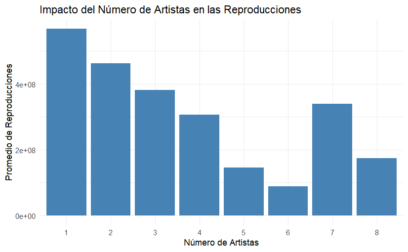

```r
library(dplyr)
library(ggplot2)
library(readr)


spotify_data <- read_csv("Spotify Most Streamed Songs.csv")
spotify_data$streams <- as.numeric(spotify_data$streams)
spotify_data$artist_count <- as.numeric(spotify_data$artist_count)


artist_impact <- spotify_data %>%
  group_by(artist_count) %>%
  summarise(
    avg_streams = mean(streams, na.rm = TRUE),
    count_songs = n()
  ) %>%
  arrange(desc(avg_streams))


ggplot(artist_impact, aes(x = factor(artist_count), y = avg_streams)) +
  geom_bar(stat = "identity", fill = "steelblue") +
  labs(
    title = "Impacto del Número de Artistas en las Reproducciones",
    x = "Número de Artistas",
    y = "Promedio de Reproducciones"
  ) +
  theme_minimal()
```

### Conclusiones:

Se puede notar que, en general, las canciones con un solo artista suelen tener más reproducciones. Sin embargo, a medida que aumenta el número de artistas, las reproducciones tienden a disminuir, con la excepción de las canciones que cuentan con 7 artistas, donde se observa un aumento en las reproducciones.

### Resumen estadístico

```r
library(dplyr)

# Análisis estadístico con desviación estándar
summary_stats <- popular_artists %>%
  summarise(
    total_artists = n(),
    avg_streams = mean(total_streams, na.rm = TRUE),
    max_streams = max(total_streams, na.rm = TRUE),
    min_streams = min(total_streams, na.rm = TRUE),
    std_dev_streams = sd(total_streams, na.rm = TRUE)
  )

# Mostrar estadísticas
print(summary_stats)
```

| total_artists | avg_streams | max_streams | min_streams | std_dev_streams |
| --- | --- | --- | --- | --- |
| 645 | 758.8509 | 14185.55 | 0 | 1400.37 |

```r
NA
```

### Dividir en conjunto de entrenamiento y prueba

- **Residuos**: Diferencia entre valores reales y predichos. Los negativos indican que el modelo sobreestimó.
- **Valor p**: Evalúa si una variable tiene un efecto real. Un valor p pequeño indica alta significancia.
- **Estadístico t**: Mide la fuerza de la relación entre variables. Valores altos indican relaciones fuertes.
- **Asteriscos**: Indican niveles de significancia. Más asteriscos = más confianza en la variable.
- **R²**: Porcentaje de variabilidad explicado por el modelo (62.48% aquí).
- **F-statistic**: Evalúa si el modelo completo es significativo; un valor alto y p pequeño confirman su relevancia.

```r
set.seed(123)
train_indices <- sample(1:nrow(spotify_data), size = 0.8 * nrow(spotify_data))
train_data <- spotify_data[train_indices, ]
test_data <- spotify_data[-train_indices, ]

## Modelo de regresión lineal
model <- lm(streams ~ in_spotify_playlists, data = train_data)
summary(model)
```

```
Call:
lm(formula = streams ~ in_spotify_playlists, data = train_data)

Residuals:
       Min         1Q     Median         3Q        Max
-2.290e+09 -1.728e+08 -8.061e+07  9.513e+07  1.652e+09

Coefficients:
                      Estimate Std. Error t value Pr(>|t|)
(Intercept)          224041570   15372591   14.57   <2e-16 ***
in_spotify_playlists     56709       1595   35.55   <2e-16 ***
---
Signif. codes:  0 ‘***’ 0.001 ‘**’ 0.01 ‘*’ 0.05 ‘.’ 0.1 ‘ ’ 1

Residual standard error: 355200000 on 759 degrees of freedom
  (1 observation deleted due to missingness)
Multiple R-squared:  0.6248,    Adjusted R-squared:  0.6244
F-statistic:  1264 on 1 and 759 DF,  p-value: < 2.2e-16
```

```r
## Predicción en el conjunto de prueba
test_data$predicted_streams <- predict(model, test_data)
```

### Visualización del modelo

### Visualización de predicciones

Hay una variabilidad significativa en el número de streams para un determinado número de listas de reproducción, como lo indican los puntos de datos dispersos alrededor de la línea de tendencia.

La línea de tendencia sugiere una relación lineal general, pero probablemente haya otros factores más allá del número de listas de reproducción que influyan en el número de streams.

```r
library(ggplot2)

r_squared <- summary(model)$r.squared
mse <- mean((test_data$streams - test_data$predicted_streams)^2)

cat("R² del modelo:", round(r_squared, 2), "\n")
```

```
R² del modelo: 0.62
```

```r
cat("Error cuadrático medio (MSE):", round(mse, 2), "\n")
```

```
Error cuadrático medio (MSE): 1.007052e+17
```

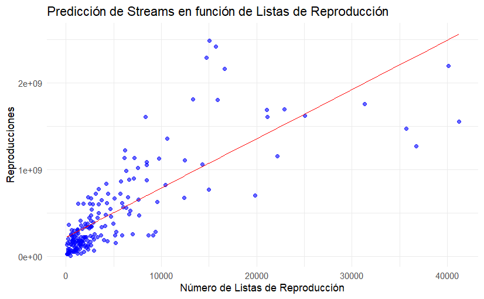

```r
# Gráfico
ggplot(test_data, aes(x = in_spotify_playlists, y = streams)) +
  geom_point(alpha = 0.6, color = "blue") +
  geom_line(aes(y = predicted_streams), color = "red") +
  labs(
    title = "Predicción de Streams en función de Listas de Reproducción",
    x = "Número de Listas de Reproducción",
    y = "Reproducciones"
  ) +
  theme_minimal()
```

# 8. Plan de mejoras

# Ciclo de vida a 3, 6 y 12 meses

“Plan de mejoras:- 3 meses: Optimización del manejo de datos faltantes y generación de nuevos gráficos interactivos

Plan de mejoras- 6 meses: Introducción de modelos predictivos avanzados como árboles de decisión o random forest

Plan de mejoras- 12 meses: Implementación de un sistema automatizado para análisis continuo del dataset y actualizaciones en tiempo real.

### Conclusión final:

El modelo de regresión tuvo limitaciones, evidenciando la necesidad de métodos más avanzados para predecir tendencias. Este proyecto permitió aplicar análisis de datos y reflexionar sobre la complejidad del éxito musical, abriendo camino a futuras investigaciones.